# **Prática 4 Parte 1A - Transfer Learning con YOLO11 - Dataset de cartas de póker**

### **Integrantes:**

- Henry Tacuri
- Franklin Guapisaca

### **Instalación de las librerías necesarias**

```python
%pip install ultralytics
%pip install supervision
%pip install onnx
import ultralytics
ultralytics.checks()
```

```
Ultralytics 8.3.53 🚀 Python-3.10.12 torch-2.5.1+cu121 CUDA:0 (Tesla T4, 15102MiB)
Setup complete ✅ (2 CPUs, 12.7 GB RAM, 32.8/112.6 GB disk)
```

### **Verificamos que las herramientas estén correctamente instaladas**

También se verifica que este configurada la tarjeta gráfica.

```python
ultralytics.checks()
```

```
Ultralytics 8.3.53 🚀 Python-3.10.12 torch-2.5.1+cu121 CUDA:0 (Tesla T4, 15102MiB)
Setup complete ✅ (2 CPUs, 12.7 GB RAM, 33.1/112.6 GB disk)
```

### Entrenamos el modelo YOLO (yolo11l.pt - versión large)

Epochs: 10

Tamaaño de entrada de la imagen (imgsz = 640)

```python
!yolo task=detect mode=train model=yolo11l.pt data=/content/datasets/PokerCards/data.yaml epochs=10 imgsz=640 plots=True
```

```
Downloading https://github.com/ultralytics/assets/releases/download/v8.3.0/yolo11l.pt to 'yolo11l.pt'...
100% 49.0M/49.0M [00:00<00:00, 245MB/s]
Ultralytics 8.3.53 🚀 Python-3.10.12 torch-2.5.1+cu121 CUDA:0 (Tesla T4, 15102MiB)
engine/trainer: task=detect, mode=train, model=yolo11l.pt, data=/content/datasets/PokerCards/data.yaml, epochs=10, time=None, patience=100, batch=16, imgsz=640, save=True, save_period=-1, cache=False, device=None, workers=8, project=None, name=train5, exist_ok=False, pretrained=True, optimizer=auto,…
Overriding model.yaml nc=80 with nc=53

                   from  n    params  module                                       arguments
  0                  -1  1      1856  ultralytics.nn.modules.conv.Conv             [3, 64, 3, 2]
  1                  -1  1     73984  ultralytics.nn.modules.conv.Conv             [64, 128, 3, 2]
  2                  -1  2    173824  ultralytics.nn.modules.block.C3k2            [128, 256, 2, True, 0.25]
  3                  -1  1    590336  ultralytics.nn.modules.conv.Conv             [256, 256, 3, 2]
  4                  -1  2    691712  ultralytics.nn.modules.block.C3k2            [256, 512, 2, True, 0.25]
  5                  -1  1   2360320  ultralytics.nn.modules.conv.Conv             [512, 512, 3, 2]
  6                  -1  2   2234368  ultralytics.nn.modules.block.C3k2            [512, 512, 2, True]
  7                  -1  1   2360320  ultralytics.nn.modules.conv.Conv             [512, 512, 3, 2]
  8                  -1  2   2234368  ultralytics.nn.modules.block.C3k2            [512, 512, 2, True]
  9                  -1  1    656896  ultralytics.nn.modules.block.SPPF            [512, 512, 5]
 10                  -1  2   1455616  ultralytics.nn.modules.block.C2PSA           [512, 512, 2]
 11                  -1  1         0  torch.nn.modules.upsampling.Upsample         [None, 2, 'nearest']
 12             [-1, 6]  1         0  ultralytics.nn.modules.conv.Concat           [1]
 13                  -1  2   2496512  ultralytics.nn.modules.block.C3k2            [1024, 512, 2, True]
 14                  -1  1         0  torch.nn.modules.upsampling.Upsample         [None, 2, 'nearest']
 15             [-1, 4]  1         0  ultralytics.nn.modules.conv.Concat           [1]
 16                  -1  2    756736  ultralytics.nn.modules.block.C3k2            [1024, 256, 2, True]
 17                  -1  1    590336  ultralytics.nn.modules.conv.Conv             [256, 256, 3, 2]
 18            [-1, 13]  1         0  ultralytics.nn.modules.conv.Concat           [1]
 19                  -1  2   2365440  ultralytics.nn.modules.block.C3k2            [768, 512, 2, True]
 20                  -1  1   2360320  ultralytics.nn.modules.conv.Conv             [512, 512, 3, 2]
 21            [-1, 10]  1         0  ultralytics.nn.modules.conv.Concat           [1]
 22                  -1  2   2496512  ultralytics.nn.modules.block.C3k2            [1024, 512, 2, True]
 23        [16, 19, 22]  1   1451887  ultralytics.nn.modules.head.Detect           [53, [256, 512, 512]]
YOLO11l summary: 631 layers, 25,351,343 parameters, 25,351,327 gradients, 87.5 GFLOPs

Transferred 1009/1015 items from pretrained weights
TensorBoard: Start with 'tensorboard --logdir runs/detect/train5', view at http://localhost:6006/
Freezing layer 'model.23.dfl.conv.weight'
AMP: running Automatic Mixed Precision (AMP) checks...
Downloading https://github.com/ultralytics/assets/releases/download/v8.3.0/yolo11n.pt to 'yolo11n.pt'...
100% 5.35M/5.35M [00:00<00:00, 107MB/s]
AMP: checks passed ✅
```

[output cut: 113 more lines]

```
            J Diamonds         16         16      0.985          1      0.995      0.973
              J Hearts         17         17      0.994          1      0.995      0.902
              J Spades         15         15      0.985          1      0.995      0.872
            J Trefoils         18         18      0.937          1      0.995      0.958
            K Diamonds         16         16          1      0.955      0.995      0.984
              K Hearts         17         17      0.987          1      0.995      0.917
              K Spades         15         15      0.986          1      0.995      0.886
            K Trefoils         18         18      0.945      0.948      0.992      0.983
            Q Diamonds         16         16       0.93          1      0.995      0.989
              Q Hearts         17         17      0.986          1      0.995      0.903
              Q Spades         15         15      0.987          1      0.995      0.915
            Q Trefoils         18         18          1      0.983      0.995      0.964
Speed: 0.2ms preprocess, 10.6ms inference, 0.0ms loss, 2.6ms postprocess per image
Results saved to runs/detect/train5
💡 Learn more at https://docs.ultralytics.com/modes/train
```

```python
!ls /content/runs/detect/train5/
```

```
args.yaml					    PR_curve.png	   val_batch0_pred.jpg
confusion_matrix_normalized.png			    R_curve.png		   val_batch1_labels.jpg
confusion_matrix.png				    results.csv		   val_batch1_pred.jpg
events.out.tfevents.1735014739.f91a36e1cc38.6321.0  results.png		   val_batch2_labels.jpg
F1_curve.png					    train_batch0.jpg	   val_batch2_pred.jpg
labels_correlogram.jpg				    train_batch1.jpg	   weights
labels.jpg					    train_batch2.jpg
P_curve.png					    val_batch0_labels.jpg
```

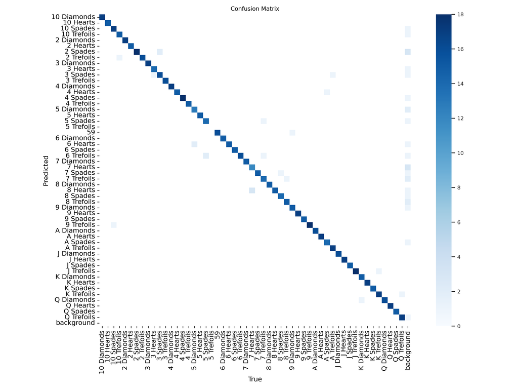

```python
from IPython.display import Image as IPyImage

IPyImage(filename=f'/content/runs/detect/train5/confusion_matrix.png', width=600)
```

### **Calidad del modelo YOLO**

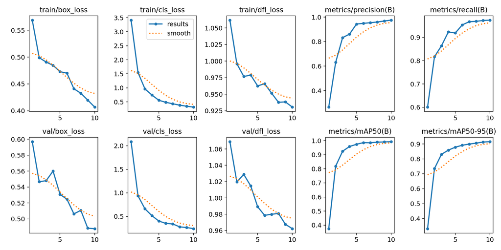

```python
from IPython.display import Image as IPyImage

IPyImage(filename=f'/content/runs/detect/train5/results.png', width=600)
```

### Métricas de Desempeño

1. **precision**:
   - Aumenta progresivamente, estabilizándose en valores altos. Esto indica que las predicciones positivas del modelo son mayormente correctas (baja tasa de falsos positivos).
2. **Recall**:
   - Mejora notablemente durante las primeras épocas y se estabiliza en niveles cercanos al máximo. Esto muestra que el modelo está capturando la mayoría de los objetos relevantes (baja tasa de falsos negativos).
3. **mAP50 y mAP50-95**:
   - Ambas métricas aumentan significativamente, alcanzando valores altos hacia el final del entrenamiento. Esto refleja que el modelo tiene un excelente rendimiento en detección para diferentes umbrales de IoU.
- El modelo muestra una tendencia clara de mejora en todas las métricas de desempeño y una reducción de las pérdidas tanto en el conjunto de entrenamiento como en el de validación. Esto indica que el modelo está aprendiendo de manera adecuada sin signos evidentes de sobreajuste o subajuste.
- Las métricas finales de precisión, recall y mAP son altas, lo que sugiere que el modelo es capaz de realizar detecciones precisas y completas en las imágenes de cartas de póker.

### **Pruebas de detección de las cartas de póker**

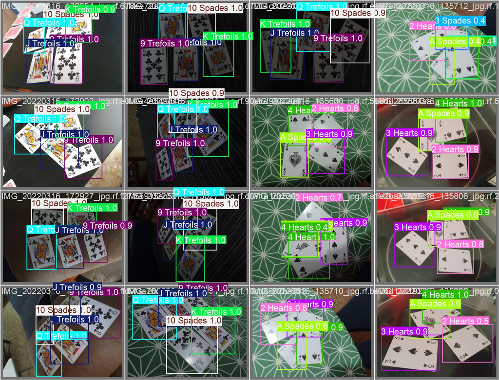

```python
from IPython.display import Image as IPyImage

IPyImage(filename=f'/content/runs/detect/train5/val_batch0_pred.jpg', width=600)
```

### **Evaluamos el modelo YOLO con los datos de validación**

```python
!yolo task=detect mode=val model=/content/runs/detect/train5/weights/best.pt data=/content/datasets/PokerCards/data.yaml
```

```
Ultralytics 8.3.53 🚀 Python-3.10.12 torch-2.5.1+cu121 CUDA:0 (Tesla T4, 15102MiB)
YOLO11l summary (fused): 464 layers, 25,320,175 parameters, 0 gradients, 86.8 GFLOPs
val: Scanning /content/datasets/PokerCards/valid/labels.cache... 193 images, 0 backgrounds, 0 corrupt: 100% 193/193 [00:00<?, ?it/s]
                 Class     Images  Instances      Box(P          R      mAP50  mAP50-95): 100% 13/13 [00:07<00:00,  1.82it/s]
                   all        193        838      0.975      0.974      0.993      0.915
           10 Diamonds         17         17      0.987          1      0.995      0.867
             10 Hearts         15         15      0.985          1      0.995      0.899
             10 Spades         18         18          1      0.964      0.995      0.959
           10 Trefoils         16         16      0.998          1      0.995      0.875
            2 Diamonds         17         17      0.999          1      0.995      0.869
              2 Hearts         15         15          1      0.885      0.995        0.8
              2 Spades         18         18      0.894      0.944      0.986      0.965
            2 Trefoils         16         16      0.982          1      0.995      0.957
            3 Diamonds         17         17      0.984          1      0.995      0.919
              3 Hearts         15         15      0.991          1      0.995      0.783
              3 Spades         18         18      0.982      0.833      0.979      0.957
            3 Trefoils         16         16      0.985          1      0.995      0.955
            4 Diamonds         17         17          1      0.995      0.995      0.877
              4 Hearts         15         15       0.97      0.933      0.991      0.835
              4 Spades         18         18      0.976          1      0.995      0.966
            4 Trefoils         15         15      0.987          1      0.995      0.941
            5 Diamonds         15         15          1      0.913      0.995      0.872
              5 Hearts         15         15      0.984          1      0.995      0.865
              5 Spades         16         16       0.96      0.875      0.949      0.933
                    59         16         16      0.974          1      0.995      0.973
            6 Diamonds         15         15      0.989          1      0.995      0.957
              6 Hearts         15         15      0.934          1      0.995      0.884
              6 Spades         15         15      0.985          1      0.995      0.885
            6 Trefoils         16         16      0.898      0.938      0.985      0.985
            7 Diamonds         15         15      0.978          1      0.995      0.995
              7 Hearts         15         15      0.997          1      0.995      0.884
              7 Spades         15         15      0.922          1      0.991      0.875
            7 Trefoils         16         16      0.953      0.875      0.978      0.959
            8 Diamonds         15         15      0.988          1      0.995      0.989
              8 Hearts         15         15      0.859          1      0.995      0.869
              8 Spades         15         15      0.976      0.933      0.985       0.85
            8 Trefoils         16         16          1      0.909      0.991      0.922
            9 Diamonds         16         16       0.99          1      0.995      0.955
              9 Hearts         17         17      0.984          1      0.995      0.911
              9 Spades         15         15      0.987          1      0.995      0.892
            9 Trefoils         18         18      0.944          1      0.995      0.985
            A Diamonds         16         16      0.989          1      0.995      0.904
              A Hearts         17         17      0.986          1      0.995      0.904
              A Spades         15         15          1      0.841      0.995      0.693
            A Trefoils         18         18          1       0.94      0.992      0.974
            J Diamonds         16         16      0.985          1      0.995      0.973
              J Hearts         17         17      0.994          1      0.995      0.902
              J Spades         15         15      0.986          1      0.995      0.872
            J Trefoils         18         18      0.937          1      0.995      0.958
            K Diamonds         16         16          1      0.955      0.995      0.984
              K Hearts         17         17      0.987          1      0.995      0.917
              K Spades         15         15      0.986          1      0.995      0.885
            K Trefoils         18         18      0.945      0.948      0.992      0.983
            Q Diamonds         16         16      0.931          1      0.995      0.989
              Q Hearts         17         17      0.986          1      0.995      0.888
              Q Spades         15         15      0.987          1      0.995      0.919
            Q Trefoils         18         18          1      0.983      0.995      0.964
Speed: 1.3ms preprocess, 23.2ms inference, 0.0ms loss, 3.9ms postprocess per image
Results saved to runs/detect/val
💡 Learn more at https://docs.ultralytics.com/modes/val
```

### **Realizamos las predicciones con nuevas imágenes**

```python
!yolo task=detect mode=predict model=/content/runs/detect/train5/weights/best.pt conf=0.25 source=/content/datasets/PokerCards/test/images save=True
```

```
Ultralytics 8.3.53 🚀 Python-3.10.12 torch-2.5.1+cu121 CUDA:0 (Tesla T4, 15102MiB)
YOLO11l summary (fused): 464 layers, 25,320,175 parameters, 0 gradients, 86.8 GFLOPs

image 1/128 /content/datasets/PokerCards/test/images/IMG_20220316_135316_jpg.rf.73bfd93ba6f1293a44936e5ed9656fa4.jpg: 480x640 1 3 Hearts, 1 4 Hearts, 1 A Spades, 76.3ms
image 2/128 /content/datasets/PokerCards/test/images/IMG_20220316_135319_jpg.rf.f2eb8cd855cd211a94b86697ae9f3c78.jpg: 480x640 1 2 Hearts, 1 3 Hearts, 1 4 Hearts, 1 A Spades, 37.8ms
image 3/128 /content/datasets/PokerCards/test/images/IMG_20220316_135321_jpg.rf.16f3952b7a317168f325e4c7e30acfcc.jpg: 480x640 1 2 Hearts, 1 3 Hearts, 1 4 Hearts, 1 A Spades, 37.8ms
image 4/128 /content/datasets/PokerCards/test/images/IMG_20220316_135327_jpg.rf.471d0c3c424beb6f47cc5443f58ff3c5.jpg: 480x640 1 2 Hearts, 1 3 Hearts, 2 4 Heartss, 1 A Spades, 35.3ms
image 5/128 /content/datasets/PokerCards/test/images/IMG_20220316_135507_jpg.rf.6ee030e8c20b41ac87fc358e892c965e.jpg: 480x640 1 2 Hearts, 1 3 Hearts, 1 4 Hearts, 1 A Spades, 32.2ms
image 6/128 /content/datasets/PokerCards/test/images/IMG_20220316_135510_jpg.rf.bc7526acb203b9411015df006b8a753d.jpg: 480x640 1 2 Hearts, 1 3 Hearts, 1 4 Hearts, 1 A Spades, 32.3ms
image 7/128 /content/datasets/PokerCards/test/images/IMG_20220316_135518_jpg.rf.4ed706c8845ed18c358f9add16a79971.jpg: 480x640 1 2 Hearts, 1 3 Hearts, 1 4 Hearts, 1 A Spades, 32.3ms
image 8/128 /content/datasets/PokerCards/test/images/IMG_20220316_135524_jpg.rf.8bb9a2953a88ff823a7ddc20518807dc.jpg: 480x640 2 3 Heartss, 1 4 Hearts, 1 A Spades, 32.2ms
image 9/128 /content/datasets/PokerCards/test/images/IMG_20220316_135537_jpg.rf.c719aff6f2cee0e329c64ec3ec1c2680.jpg: 480x640 2 3 Heartss, 1 4 Hearts, 1 A Spades, 20.5ms
image 10/128 /content/datasets/PokerCards/test/images/IMG_20220316_135539_jpg.rf.30e126886c70bd743610060a13a81846.jpg: 480x640 1 2 Hearts, 1 3 Hearts, 1 4 Hearts, 1 A Spades, 20.5ms
image 11/128 /content/datasets/PokerCards/test/images/IMG_20220316_140335_jpg.rf.116eaac86a0b550f9899a5263cc520fe.jpg: 480x640 1 5 Hearts, 1 6 Spades, 1 7 Spades, 2 8 Spadess, 20.5ms
image 12/128 /content/datasets/PokerCards/test/images/IMG_20220316_140440_jpg.rf.a6504550a538baccf6aa01c697766f85.jpg: 480x640 1 5 Hearts, 1 6 Spades, 1 7 Spades, 1 8 Spades, 19.8ms
image 13/128 /content/datasets/PokerCards/test/images/IMG_20220316_140454_jpg.rf.83114fc4932e654b0ec2a7fa1cad97e5.jpg: 480x640 1 5 Hearts, 1 6 Spades, 1 7 Spades, 1 8 Spades, 19.8ms
image 14/128 /content/datasets/PokerCards/test/images/IMG_20220316_140527_jpg.rf.5623ebe529fd1db2d4ad5d485b6f435d.jpg: 480x640 1 5 Hearts, 1 6 Spades, 1 7 Spades, 1 8 Spades, 19.6ms
image 15/128 /content/datasets/PokerCards/test/images/IMG_20220316_140556_jpg.rf.886f7a560f3363735b67fcb775eb3ba2.jpg: 480x640 1 5 Hearts, 1 6 Spades, 1 7 Spades, 1 8 Spades, 18.1ms
image 16/128 /content/datasets/PokerCards/test/images/IMG_20220316_140723_jpg.rf.ac02b0dbc7aef4d121837edd19faccc6.jpg: 480x640 1 5 Hearts, 1 6 Spades, 1 7 Spades, 1 8 Spades, 17.7ms
image 17/128 /content/datasets/PokerCards/test/images/IMG_20220316_140831_jpg.rf.eb9516d4293c148c734d0f55f5ea9fab.jpg: 480x640 1 5 Hearts, 1 6 Spades, 1 7 Spades, 1 8 Spades, 18.5ms
image 18/128 /content/datasets/PokerCards/test/images/IMG_20220316_140905_jpg.rf.b6cb5ade45d5dfe2dc9eee3f723e3a62.jpg: 480x640 1 5 Hearts, 1 6 Spades, 1 7 Spades, 1 8 Spades, 17.7ms
image 19/128 /content/datasets/PokerCards/test/images/IMG_20220316_140913_jpg.rf.6efc103c2f2e5a6747a8cab92b8df27c.jpg: 480x640 1 5 Hearts, 1 6 Spades, 1 7 Spades, 1 8 Spades, 18.4ms
image 20/128 /content/datasets/PokerCards/test/images/IMG_20220316_140947_jpg.rf.04c78d89327b89b0f0b56294acc534b0.jpg: 480x640 1 5 Hearts, 1 6 Spades, 1 7 Spades, 1 8 Spades, 17.7ms
image 21/128 /content/datasets/PokerCards/test/images/IMG_20220316_141436_jpg.rf.1d6ab56605154243987de9721638c403.jpg: 480x640 1 10 Hearts, 1 9 Spades, 1 J Spades, 1 K Spades, 1 Q Spades, 18.1ms
image 22/128 /content/datasets/PokerCards/test/images/IMG_20220316_141442_jpg.rf.49cce377656f3130eb889fa49dafb346.jpg: 480x640 1 10 Hearts, 1 9 Spades, 1 J Spades, 1 K Spades, 1 Q Spades, 18.0ms
image 23/128 /content/datasets/PokerCards/test/images/IMG_20220316_141504_jpg.rf.a8bd197ffdd990e39c6abcfde6a352ae.jpg: 480x640 1 10 Hearts, 1 9 Spades, 1 J Spades, 1 K Spades, 1 Q Spades, 18.7ms
```

[output cut: 108 more lines]

### **Mostramos las precciones de las nuevas imágenes**

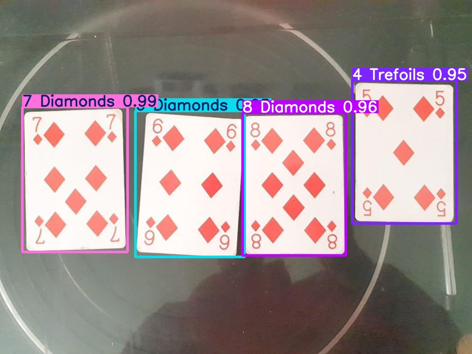

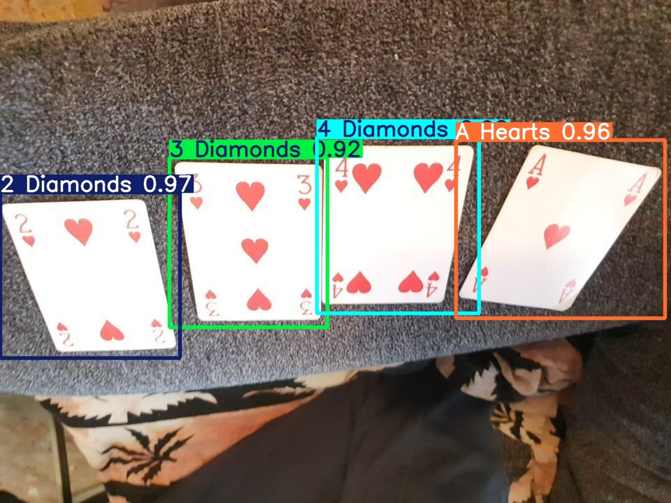

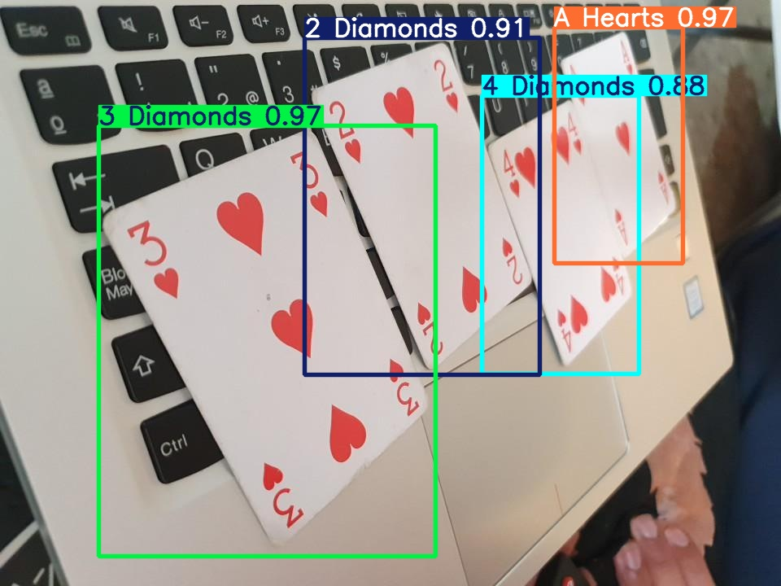

```python
import glob
import os
from IPython.display import Image as IPyImage, display

latest_folder = max(glob.glob('/content/runs/detect/predict*/'), key=os.path.getmtime)
for img in glob.glob(f'{latest_folder}/*.jpg')[:3]:
    display(IPyImage(filename=img, width=600))
    print("\n")
```

### **Exportamos el modelo YOLO al formato onnx para poder utilizarlo en C++ y OpenCV**

```python
from ultralytics import YOLO

model = YOLO('/content/runs/detect/train5/weights/best.pt')
```

```python
model.export(format = 'onnx', opset = 12, simplify = False, half = False, device = 'gpu')
```

```
Ultralytics 8.3.53 🚀 Python-3.10.12 torch-2.5.1+cu121 CUDA:gpu (Tesla T4, 15102MiB)
YOLO11l summary (fused): 464 layers, 25,320,175 parameters, 0 gradients, 86.8 GFLOPs

PyTorch: starting from '/content/runs/detect/train5/weights/best.pt' with input shape (1, 3, 640, 640) BCHW and output shape(s) (1, 57, 8400) (48.9 MB)

ONNX: starting export with onnx 1.17.0 opset 12...
ONNX: export success ✅ 2.6s, saved as '/content/runs/detect/train5/weights/best.onnx' (96.9 MB)

Export complete (3.9s)
Results saved to /content/runs/detect/train5/weights
Predict:         yolo predict task=detect model=/content/runs/detect/train5/weights/best.onnx imgsz=640
Validate:        yolo val task=detect model=/content/runs/detect/train5/weights/best.onnx imgsz=640 data=/content/datasets/PokerCards/data.yaml
Visualize:       https://netron.app
```

```
'/content/runs/detect/train5/weights/best.onnx'
```